# Exercise 4_2: Subsetting and Linking

Introduction to Geospatial Techniques for Social Scientists in R

Author

Stefan Jünger & Dennis Abel

### Exercises

**🏋 Exercise 1**

Import the ESRI shapefile of German districts and the district attribute table. Join the two data frames, transform the CRS to `EPSG:3035`, and check your output.

**💡 Tip**

You can use base R’s `merge()` function or `dplyr`’s `dplyr::left_join()`. Plus, you need the function `sf::st_transform()` to change the CRS.

**🏋 Exercise 2**

We want a first descriptive visual of the distribution of charging stations in Cologne (or any other district of your choice) and the surrounding districts. Filter the district of Cologne (`AGS == "05315"`) and find the surrounding districts. Calculate the number of chargers per district (`charger_count`) and the number of chargers per 1,000 inhabitants in each district (`charger_dens`). Plot the two columns for Cologne and its surrounding districts.

**💡 Tip**

You can use the `dplyr` function `dplyr::bind_rows()` to combine the two spatial objects, “Cologne” and “Cologne Surroundings”.

**🏋 Exercise 3**

To wrap up, let’s do some stuff with other data formats. Sample 50 points that fall within the boundaries of the city of Cologne.

**💡 Tip**

Sampling is straightforward: Apply the `sf::st_sample` to the Cologne vector data, but make sure to apply the `sf::st_as_sf()` function afterward to receive a full-fledged data table (with a geometry column only).

**🏋 Exercise 4**

Create a new raster layer comprising Cologne’s immigrant rates based on the raster layers from the previous exercises. Extract the immigrant rate value at each position of the previously sampled points as a vector. What is your observation?

**💡 Tip**

You need the `immigrants_cologne.tif` and `inhabitants_cologne.tif` files in the `./data` folder. Due to severe data protection measures, the German Census 2011 data could be more sparse.

**🏋 Exercise 5**

Use an adequate method of raster extraction to gather information in the geographic surroundings of a point. What is your observation now?

**💡 Tip**

Assume that people move in a 1,000-meter radius around their location. Thus, extracting information on buffers of 1,000 meters around the points might be interesting using the option `sf::st_buffer()` function. In that case, you should also set a descriptive statistics function, e.g., with the option `fun = mean` and its helpful companion option to consider missing values `na.rm = TRUE`.

### Solutions

**✅ Solution 1**

```r
# load libraries
library(sf)
library(dplyr)

# Import data
german_districts <-
  sf::read_sf("./data/VG250_KRS.shp") |>
  sf::st_transform(3035) |>
  dplyr::select(AGS, GEN)

attributes_districts <-
  readr::read_delim("./data/attributes_districts.csv", delim = ";")

# Join data and transform
german_districts_enhanced <-
  german_districts |>
  dplyr::left_join(attributes_districts, by = "AGS")

# Check
sf::st_crs(german_districts_enhanced)

head(german_districts_enhanced, 2)
```

```
Coordinate Reference System:
  User input: EPSG:3035
  wkt:
PROJCRS["ETRS89-extended / LAEA Europe",
    BASEGEOGCRS["ETRS89",
        ENSEMBLE["European Terrestrial Reference System 1989 ensemble",
            MEMBER["European Terrestrial Reference Frame 1989"],
            MEMBER["European Terrestrial Reference Frame 1990"],
            MEMBER["European Terrestrial Reference Frame 1991"],
            MEMBER["European Terrestrial Reference Frame 1992"],
            MEMBER["European Terrestrial Reference Frame 1993"],
            MEMBER["European Terrestrial Reference Frame 1994"],
            MEMBER["European Terrestrial Reference Frame 1996"],
            MEMBER["European Terrestrial Reference Frame 1997"],
            MEMBER["European Terrestrial Reference Frame 2000"],
            MEMBER["European Terrestrial Reference Frame 2005"],
            MEMBER["European Terrestrial Reference Frame 2014"],
            MEMBER["European Terrestrial Reference Frame 2020"],
            ELLIPSOID["GRS 1980",6378137,298.257222101,
                LENGTHUNIT["metre",1]],
            ENSEMBLEACCURACY[0.1]],
        PRIMEM["Greenwich",0,
            ANGLEUNIT["degree",0.0174532925199433]],
        ID["EPSG",4258]],
    CONVERSION["Europe Equal Area 2001",
        METHOD["Lambert Azimuthal Equal Area",
            ID["EPSG",9820]],
        PARAMETER["Latitude of natural origin",52,
            ANGLEUNIT["degree",0.0174532925199433],
            ID["EPSG",8801]],
        PARAMETER["Longitude of natural origin",10,
            ANGLEUNIT["degree",0.0174532925199433],
            ID["EPSG",8802]],
        PARAMETER["False easting",4321000,
            LENGTHUNIT["metre",1],
            ID["EPSG",8806]],
        PARAMETER["False northing",3210000,
            LENGTHUNIT["metre",1],
            ID["EPSG",8807]]],
    CS[Cartesian,2],
        AXIS["northing (Y)",north,
            ORDER[1],
            LENGTHUNIT["metre",1]],
        AXIS["easting (X)",east,
            ORDER[2],
            LENGTHUNIT["metre",1]],
    USAGE[
        SCOPE["Statistical analysis."],
        AREA["Europe - European Union (EU) countries and candidates. Europe - onshore and offshore: Albania; Andorra; Austria; Belgium; Bosnia and Herzegovina; Bulgaria; Croatia; Cyprus; Czechia; Denmark; Estonia; Faroe Islands; Finland; France; Germany; Gibraltar; Greece; Hungary; Iceland; Ireland;…
        BBOX[24.6,-35.58,84.73,44.83]],
    ID["EPSG",3035]]
```

```
Simple feature collection with 2 features and 8 fields
Geometry type: MULTIPOLYGON
Dimension:     XY
Bounding box:  xmin: 4279627 ymin: 3460480 xmax: 4335232 ymax: 3524426
Projected CRS: ETRS89-extended / LAEA Europe
# A tibble: 2 × 9
  AGS   GEN                                      geometry car_density ecar_share
  <chr> <chr>                          <MULTIPOLYGON [m]>       <dbl>      <dbl>
1 01001 Flensburg (((4283235 3524256, 4283267 3524100, 4…        4915        2.4
2 01002 Kiel      (((4331981 3480575, 4332008 3480496, 4…        4528        2.2
# ℹ 4 more variables: publictransport_meandist <dbl>, population <dbl>,
#   green_voteshare <dbl>, afd_voteshare <dbl>
```

**✅ Solution 2**

```r
# filter Cologne
cologne <-
  german_districts |>
  dplyr::filter(AGS == "05315")

# filter surrounding districts, append with Cologne data and select the charger column
cologne_sur <-
  german_districts |>
  dplyr::filter(lengths(sf::st_touches(german_districts, cologne)) > 0) |>
  dplyr::bind_rows(cologne)


# one pipe to rule them all
cologne_sur_enhanced  <-
  readr::read_delim("./data/charging_points_ger.csv", delim =";") |>
  dplyr::filter(!is.na(longitude) & !is.na(latitude)) |>
  sf::st_as_sf(coords = c("longitude", "latitude"), crs = 4326) |>
  sf::st_transform(crs = 3035) |>
  sf::st_join(cologne_sur, join = sf::st_within) |>
  dplyr::group_by(AGS) |>
  dplyr::summarise(charger_count = dplyr::n()) |>
  sf::st_drop_geometry() |>
  dplyr::left_join(cologne_sur, y = _, by = "AGS") |>
  dplyr::left_join(
    attributes_districts |>
      dplyr::select(AGS, population),
    by = "AGS"
    ) |>
  dplyr::mutate(charger_dens = (charger_count*1000) / population)

# plot
cologne_sur_enhanced |>
  dplyr::select(charger_count, charger_dens) |>
  plot()
```

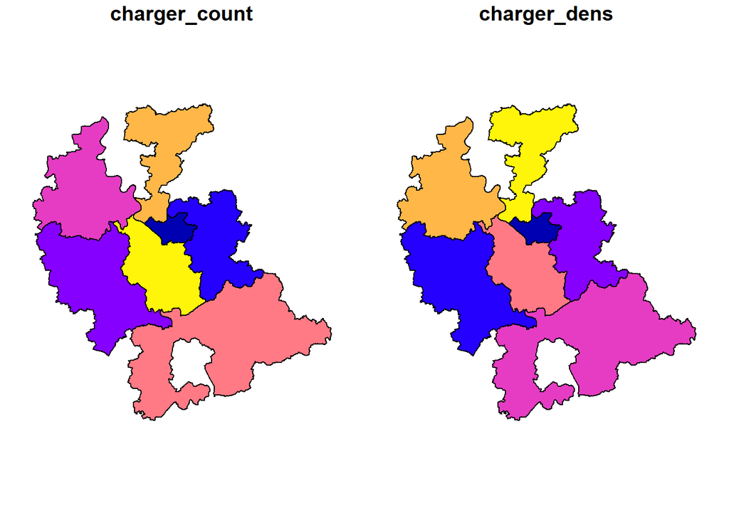

**✅ Solution 3**

```r
cologne_50_points <-
  cologne |>
  sf::st_sample(50) |>
  sf::st_as_sf()
```

**✅ Solution 4**

```r
library(terra)

immigrant_rates <-
  terra::rast("./data/immigrants_cologne.tif") * 100 /
  terra::rast("./data/inhabitants_cologne.tif")

immigrant_rates_at_point <- terra::extract(immigrant_rates, cologne_50_points)

immigrant_rates_at_point

# There are a lot of missing values.
```

```
terra 1.8.15
```

```
   ID immigrants_cologne
1   1          28.947368
2   2          32.568807
3   3                 NA
4   4                 NA
5   5                 NA
6   6           9.375000
7   7                 NA
8   8          10.752688
9   9                 NA
10 10                 NA
11 11                 NA
12 12           9.523810
13 13                 NA
14 14                 NA
```

[output cut: 36 more lines]

**✅ Solution 5**

```r
immigrant_rates_1000m_buffer <-
  terra::extract(
    immigrant_rates,
    sf::st_buffer(cologne_50_points, 1000),
    fun = mean,
    na.rm = TRUE
    )
immigrant_rates_1000m_buffer
```

```
   ID immigrants_cologne
1   1           13.75325
2   2           15.36722
3   3           12.38931
4   4           10.88890
5   5           16.34015
6   6           32.75869
7   7           14.02908
8   8           18.37278
9   9           14.86400
10 10           28.03204
11 11           17.98605
12 12           14.54929
13 13           17.49377
14 14                NaN
```

[output cut: 36 more lines]